# Prueba Machine Learning : Ramon Yañez, Patricio Zapata

24-10-2020

### PREGUNTA 1 [0.75pt]

A veces, un algoritmo de machine learning no logra modelar bien los datos de entrenamiento ni generalizarse a nuevas observaciones. Elija la opción que mejor caracteriza a esta situación y justifique su elección.  
(a) Error de clasificación bajo.  
(b) Underfitting.  
(c) La varianza del error de estimación es pequeña.  
(d) Overfitting.

**Respuesta: (b) Underfitting**  
**Justificación**: Tenemos underfitting cuando los datos son pocos y no se puede generalizar el conocimiento.Como se entrenó con poca data, al momento de recibir datos nuevos, *nuestro algoritmo hará una predicción muy poco acertada*.

[figure not shown]

### PREGUNTA 2 [0.75pt]

Hacer un árbol de decisión más profundo asegurará un mejor ajuste, pero probablemente reducirá la exactitud (accuracy) de la validación cruzada. Justifique. (a) Verdadero. (b) Falso

**Respuesta: Verdadero**  
**Justificación**: Justificación: Al tener mas profundidad, el ajuste con la data de entrenamiento calza plenamente pero cuando queremos generalizar fallará asi mismo como hacer una predicción con otra data o validación cruzada. Este efecto se conoce como Overfitting.

[figure not shown]

### PREGUNTA 3

**Creacion Data frame**

```r
mi_df <- data.frame(
  "Edad" = c("18-40", "18-40", "18-40", "18-40", "18-40", "18-40", "18-40", "41-60", "41-60" , "41-60" , "41-60" , "41-60" , "41-60" , "41-60" , ">60" , ">60", ">60", ">60", ">60", ">60", ">60" ),
  "Combo" = c("Fiesta", "Supremo", "Supremo", "Fiesta", "Supremo", "Mediano", "Supremo", "Mediano", "Mediano" , "Fiesta" , "Supremo" , "Fiesta" , "Supremo" , "Supremo" , "Fiesta" , "Mediano", "Mediano", "Fiesta", "Fiesta", "Supremo", "Supremo" )
)

new <-  table(mi_df)
new
```

```
##        Combo
## Edad    Fiesta Mediano Supremo
##   >60        3       2       2
##   18-40      2       1       4
##   41-60      2       2       3
```

**(i) [0.25pt] Convierta el conjunto de datos en una tabla de frecuencia.**

```r
datos <- prop.table(new)
datos
```

```
##        Combo
## Edad        Fiesta    Mediano    Supremo
##   >60   0.14285714 0.09523810 0.09523810
##   18-40 0.09523810 0.04761905 0.19047619
##   41-60 0.09523810 0.09523810 0.14285714
```

**(ii) [0.25pt] Obtenga las probabilidades marginales por rango de Edad y Combo.**

```r
mayor_60 <-  sum(datos[1,])
mayor_60
```

```
## [1] 0.3333333
```

```r
entre_18_40  <-  sum(datos[2,])
entre_18_40
```

```
## [1] 0.3333333
```

```r
entre_41_60  <- sum(datos[3,])
entre_41_60
```

```
## [1] 0.3333333
```

```r
Fiesta  <- sum(datos[,1])
Fiesta
```

```
## [1] 0.3333333
```

```r
Mediano  <- sum(datos[,2])
Mediano
```

```
## [1] 0.2380952
```

```r
Supremo  <- sum(datos[,3])
Supremo
```

```
## [1] 0.4285714
```

**(iii) [1.00pt] Calcule la probabilidad de recomendar cada Combo dadoel rango de Edad, es decir, la probabilidad posterior de recomendación.**

```r
# p(fiesta | mayor a 60 )
#    A           B
# =
# ( p(mayor_60 | Fiesta) * P(fiesta) )  / P(mayor_60)
mayor_60_Fiesta <- datos[1,1]
(mayor_60_Fiesta * Fiesta) / mayor_60
```

```
## [1] 0.1428571
```

```r
# p(mediano | mayor a 60 )
#    A           B
# =
# ( p(mayor_60 | Mediano) * P(Mediano) )  / P(mayor_60)
mayor_60_Mediano <- datos[1,2]
(mayor_60_Mediano * Mediano) / mayor_60
```

```
## [1] 0.06802721
```

```r
# p(supremo | mayor a 60 )
#    A           B
# =
# ( p(mayor_60 | supremo) * P(supremo) )  / P(mayor_60)
mayor_60_Supremo <- datos[1,3]
(mayor_60_Supremo * Supremo) / mayor_60
```

```
## [1] 0.122449
```

```r
# p(fiesta | 18_40 )
#    A           B
# =
# ( p(18_40 | Fiesta) * P(fiesta) )  / P(18_40)
entre_18_40_Fiesta <- datos[2,1]
(entre_18_40_Fiesta * Fiesta) / entre_18_40
```

```
## [1] 0.0952381
```

```r
# p(mediano | 18_40 )
#    A           B
# =
# ( p(18_40 | mediano) * P(mediano) )  / P(18_40)
entre_18_40_mediano <- datos[2,2]
(entre_18_40_mediano * Mediano) / entre_18_40
```

```
## [1] 0.03401361
```

```r
# p(supremo | 18_40 )
#    A           B
# =
# ( p(18_40 | supremo) * P(supremo) )  / P(18_40)
entre_18_40_supremo <- datos[2,3]
(entre_18_40_supremo * Supremo) / entre_18_40
```

```
## [1] 0.244898
```

```r
# p(fiesta | 41_60 )
#    A           B
# =
# ( p(41_60 | Fiesta) * P(fiesta) )  / P(41_60)
entre_41_60_Fiesta <- datos[3,1]
(entre_41_60_Fiesta * Fiesta) / entre_41_60
```

```
## [1] 0.0952381
```

```r
# p(mediano | 41_60 )
#    A           B
# =
# ( p(41_60 | mediano) * P(mediano) )  / P(41_60)
entre_41_60_mediano <- datos[3,2]
(entre_41_60_mediano * Mediano) / entre_41_60
```

```
## [1] 0.06802721
```

```r
# p(supremo | 41_60 )
#    A           B
# =
# ( p(41_60 | supremo) * P(supremo) )  / P(41_60)
entre_41_60_supremo <- datos[3,3]
(entre_41_60_supremo * Supremo) / entre_41_60
```

```
## [1] 0.1836735
```

**(iv) [0.25pt] Si un cliente de 30 años (es decir, rango de edad: “18-40”) se conecta al sistema, ¿qué Combo recomendaría el algoritmo?**

Le recomendaría el combo supremo ya que nos da un 24% de probabilidad que lo consuma

### PREGUNTA 4

La base de datos wine (disponible en el paquete rattle.data) contiene información de 178 vinos. Se desea clasificar el tipo de vino (Type=1,2,3) a partir de 13 covariables disponibles. Aquí hay más detalles sobre cada variable. Cargue la base de datos y desarrolle los siguientes ítems:

**(i) [0.25pt] Estandarice las variables continuas.**

```r
data <- wine
glimpse(data)
```

```
## Rows: 178
## Columns: 14
## $ Type            <fct> 1, 1, 1, 1, 1, 1, 1, 1, 1, 1, 1, 1, 1, 1, 1, 1, 1, ...
## $ Alcohol         <dbl> 14.23, 13.20, 13.16, 14.37, 13.24, 14.20, 14.39, 14...
## $ Malic           <dbl> 1.71, 1.78, 2.36, 1.95, 2.59, 1.76, 1.87, 2.15, 1.6...
## $ Ash             <dbl> 2.43, 2.14, 2.67, 2.50, 2.87, 2.45, 2.45, 2.61, 2.1...
## $ Alcalinity      <dbl> 15.6, 11.2, 18.6, 16.8, 21.0, 15.2, 14.6, 17.6, 14....
## $ Magnesium       <int> 127, 100, 101, 113, 118, 112, 96, 121, 97, 98, 105,...
## $ Phenols         <dbl> 2.80, 2.65, 2.80, 3.85, 2.80, 3.27, 2.50, 2.60, 2.8...
## $ Flavanoids      <dbl> 3.06, 2.76, 3.24, 3.49, 2.69, 3.39, 2.52, 2.51, 2.9...
## $ Nonflavanoids   <dbl> 0.28, 0.26, 0.30, 0.24, 0.39, 0.34, 0.30, 0.31, 0.2...
## $ Proanthocyanins <dbl> 2.29, 1.28, 2.81, 2.18, 1.82, 1.97, 1.98, 1.25, 1.9...
## $ Color           <dbl> 5.64, 4.38, 5.68, 7.80, 4.32, 6.75, 5.25, 5.05, 5.2...
## $ Hue             <dbl> 1.04, 1.05, 1.03, 0.86, 1.04, 1.05, 1.02, 1.06, 1.0...
## $ Dilution        <dbl> 3.92, 3.40, 3.17, 3.45, 2.93, 2.85, 3.58, 3.58, 2.8...
## $ Proline         <int> 1065, 1050, 1185, 1480, 735, 1450, 1290, 1295, 1045...
```

```r
data[,-1] <- as.data.frame(scale(data[,-1]))
summary(data)
```

```
##  Type      Alcohol             Malic              Ash
##  1:59   Min.   :-2.42739   Min.   :-1.4290   Min.   :-3.66881
##  2:71   1st Qu.:-0.78603   1st Qu.:-0.6569   1st Qu.:-0.57051
##  3:48   Median : 0.06083   Median :-0.4219   Median :-0.02375
##         Mean   : 0.00000   Mean   : 0.0000   Mean   : 0.00000
##         3rd Qu.: 0.83378   3rd Qu.: 0.6679   3rd Qu.: 0.69615
##         Max.   : 2.25341   Max.   : 3.1004   Max.   : 3.14745
##    Alcalinity          Magnesium          Phenols           Flavanoids
##  Min.   :-2.663505   Min.   :-2.0824   Min.   :-2.10132   Min.   :-1.6912
##  1st Qu.:-0.687199   1st Qu.:-0.8221   1st Qu.:-0.88298   1st Qu.:-0.8252
##  Median : 0.001514   Median :-0.1219   Median : 0.09569   Median : 0.1059
##  Mean   : 0.000000   Mean   : 0.0000   Mean   : 0.00000   Mean   : 0.0000
##  3rd Qu.: 0.600395   3rd Qu.: 0.5082   3rd Qu.: 0.80672   3rd Qu.: 0.8467
##  Max.   : 3.145637   Max.   : 4.3591   Max.   : 2.53237   Max.   : 3.0542
##  Nonflavanoids     Proanthocyanins        Color              Hue
##  Min.   :-1.8630   Min.   :-2.06321   Min.   :-1.6297   Min.   :-2.08884
##  1st Qu.:-0.7381   1st Qu.:-0.59560   1st Qu.:-0.7929   1st Qu.:-0.76540
##  Median :-0.1756   Median :-0.06272   Median :-0.1588   Median : 0.03303
##  Mean   : 0.0000   Mean   : 0.00000   Mean   : 0.0000   Mean   : 0.00000
##  3rd Qu.: 0.6078   3rd Qu.: 0.62741   3rd Qu.: 0.4926   3rd Qu.: 0.71116
##  Max.   : 2.3956   Max.   : 3.47527   Max.   : 3.4258   Max.   : 3.29241
##     Dilution          Proline
##  Min.   :-1.8897   Min.   :-1.4890
##  1st Qu.:-0.9496   1st Qu.:-0.7824
##  Median : 0.2371   Median :-0.2331
##  Mean   : 0.0000   Mean   : 0.0000
##  3rd Qu.: 0.7864   3rd Qu.: 0.7561
##  Max.   : 1.9554   Max.   : 2.9631
```

**(ii) [0.25pt] Divida la base de datos en 70% para entrenamiento y 30% para prueba (Utilice una semilla para que el resultado sea replicable).**

```r
set.seed(2020)
posTraining <- sample(1:nrow(data), 0.7*nrow(data))
data_training <- data[posTraining, ]
head(data_training)
```

```
##     Type     Alcohol      Malic        Ash Alcalinity  Magnesium    Phenols
## 156    3  0.20864312  2.5544123 -0.1695567  0.7501148 -0.4720169 -0.8869720
## 87     2 -1.03546501 -0.6501820 -0.2060072  0.9896670 -0.6820644 -0.8230590
## 22     1 -0.08698653  1.3101703  1.0333127 -0.2679823  0.1581256  0.1835703
## 65     2 -1.02314711 -0.7934041  0.5959057 -0.1482061  0.2981573 -0.6472984
## 17     1  1.60056608 -0.3726892  1.2884668  0.1512342  1.4184107  0.8067217
## 164    3 -0.05003283  0.9968720 -0.0602049 -0.2979263  0.4381890 -1.4462105
##     Flavanoids Nonflavanoids Proanthocyanins       Color        Hue    Dilution
## 156 -1.4008685     1.9938884     -0.07145670  1.22586699 -1.5638404 -1.59394458
## 87  -0.3396573     0.5475632     -0.05398515 -1.12500788  1.6299077 -0.49533822
## 22   0.3811654    -0.8987620      0.67982021 -0.24073385  0.3174085  1.27933359
## 65  -0.2795888     0.7082660     -0.97997762 -0.90933129  2.1549074 -0.53759231
## 17   1.1119995    -0.2559508      0.66234866  0.49256657  0.4924084  0.05396496
## 164 -1.3307885     0.3065090     -1.13722163  0.09572164 -1.2138406 -1.21365776
##         Proline
## 156 -0.06952283
## 87  -0.79989609
## 22   0.07337629
## 65  -1.24447112
## 17   1.69289961
## 164 -0.22829963
```

```r
data_test <- data[-posTraining, ]
head(data_test)
```

```
##    Type  Alcohol      Malic        Ash Alcalinity  Magnesium    Phenols
## 4     1 1.686791 -0.3458351  0.4865539 -0.8069748  0.9282998  2.4844372
## 6     1 1.477387 -0.5159113  0.3043010 -1.2860793  0.8582840  1.5576991
## 9     1 2.253415 -0.6233279 -0.7163155 -1.6454077 -0.1919535  0.8067217
## 11    1 1.354208 -0.1578561 -0.2424578 -0.4476464  0.3681732  1.0463954
## 12    1 1.378844 -0.7665500 -0.1695567 -0.8069748 -0.3319852 -0.1519728
## 21    1 1.304936 -0.6322793 -0.3153590 -1.0465271  1.8385057  1.1262866
##    Flavanoids Nonflavanoids Proanthocyanins       Color        Hue  Dilution
## 4   1.4623994    -0.9791134      1.02925134  1.18273167 -0.4263410 1.1807407
## 6   1.3622851    -0.1755994      0.66234866  0.72981082  0.4049085 0.3356589
## 9   0.9518167    -0.5773564      0.67982021  0.06121338  0.5361584 0.3356589
## 11  1.2922052    -1.1398162      1.37868246  0.29845763  1.2799079 0.7863692
## 12  0.4011882    -0.8184106     -0.03651359 -0.02505726  0.9299081 0.2934048
## 21  1.1420338    -0.9791134      0.88947889  0.25532232  0.5799084 1.5469428
##      Proline
## 4  2.3280068
## 6  2.2327407
## 9  0.9466487
## 11 2.4232729
## 12 1.6928996
## 21 0.1051316
```

```r
nrow(data_training) + nrow(data_test) # Corroboramos 178 filas
```

```
## [1] 178
```

**(iii) [0.25pt] Implemente los algoritmos de Random Forest (20 árboles y 4 variables) y Support Vector Machine (kernel radial) utilizando todas las variables.**

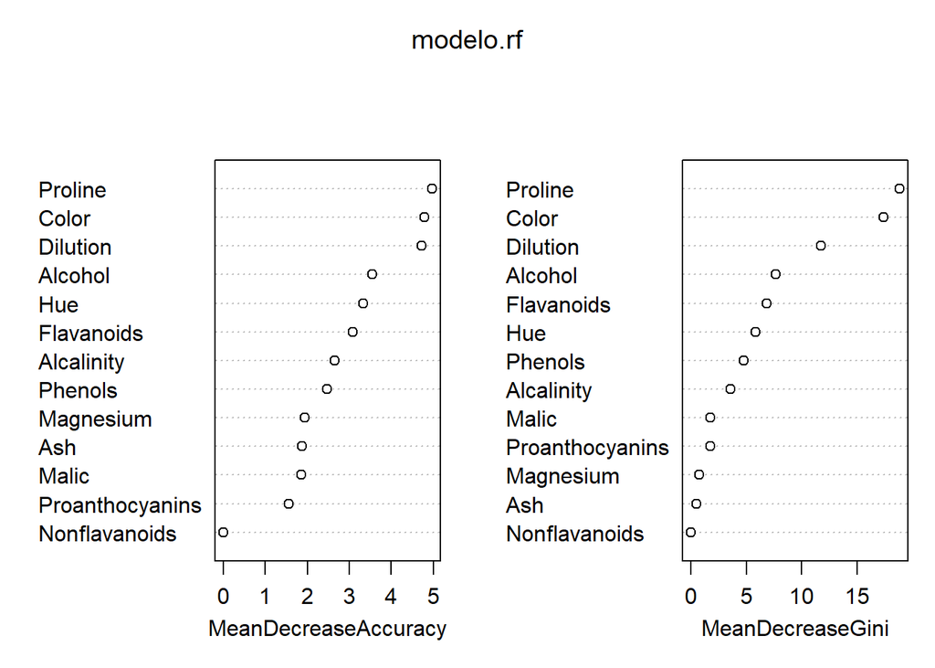

```r
# randomForest
modelo.rf <- randomForest(Type ~ ., data=data_training,
                         ntree=20, mtry=4, replace=TRUE, importance=T)

varImpPlot(modelo.rf)
```

```r
# SVM
modelo.svm <- svm(Type ~ ., data=data_training, kernel="radial")
modelo.svm
```

```
##
## Call:
## svm(formula = Type ~ ., data = data_training, kernel = "radial")
##
##
## Parameters:
##    SVM-Type:  C-classification
##  SVM-Kernel:  radial
##        cost:  1
##
## Number of Support Vectors:  58
```

**(iv) [0.25pt] ¿Cuál es el porcentaje de clasificaciones correctas para cada algoritmo utilizando la base de entrenamiento?**

### RANDOM FOREST Predicciones

```r
# Valores predictivos
predval.rf1 <- predict(modelo.rf, data_training)
# Matriz de confusión
table(data_training$Type, predval.rf1)
```

```
##    predval.rf1
##      1  2  3
##   1 45  0  0
##   2  0 44  0
##   3  0  0 35
```

```r
# % de clasificación correcta
mean(data_training$Type == predval.rf1)
```

```
## [1] 1
```

**–> El % de predicción respecto a la data de entrenamiento con modelo Random Forest es de 100%**

### SVM Predicciones

```r
predval.svm <- predict(modelo.svm, data_training)
# Matriz de confusión
table(data_training$Type, predval.svm)
```

```
##    predval.svm
##      1  2  3
##   1 45  0  0
##   2  0 44  0
##   3  0  0 35
```

```r
# % de clasificación correcta
mean(data_training$Type == predval.svm)
```

```
## [1] 1
```

**(v) [0.25pt] Aplique una validación cruzada para ambos algoritmos usando 30 folds (number) y 70% para la submuestra de entrenamiento (p). Basado en la validación cruzada, elija uno de los métodos como el más apropiado.**

### CV con Random Forest

```r
( cv_rf <- train(Type ~., data=data_training, method="rf",
                 trControl=trainControl(method="cv", number=30, p=0.7),
                 tuneGrid=expand.grid(.mtry=3)) )
```

```
## Random Forest
##
## 124 samples
##  13 predictor
##   3 classes: '1', '2', '3'
##
## No pre-processing
## Resampling: Cross-Validated (30 fold)
## Summary of sample sizes: 119, 119, 120, 120, 120, 119, ...
## Resampling results:
##
##   Accuracy   Kappa
##   0.9933333  0.9895833
##
## Tuning parameter 'mtry' was held constant at a value of 3
```

**–>La validacion cruzada da un accuracy de 0.993 para Random Forest**

# CV con SVM

```r
( cv.svm <- train(Type ~., data=data_training, method="svmRadial",
                  trControl=trainControl(method="cv", number=30, p=0.7)) )
```

```
## Support Vector Machines with Radial Basis Function Kernel
##
## 124 samples
##  13 predictor
##   3 classes: '1', '2', '3'
##
## No pre-processing
## Resampling: Cross-Validated (30 fold)
## Summary of sample sizes: 119, 118, 120, 120, 120, 121, ...
## Resampling results across tuning parameters:
##
##   C     Accuracy   Kappa
##   0.25  0.9833333  0.9757576
##   0.50  0.9833333  0.9757576
##   1.00  0.9833333  0.9745455
##
## Tuning parameter 'sigma' was held constant at a value of 0.07451907
## Accuracy was used to select the optimal model using the largest value.
## The final values used for the model were sigma = 0.07451907 and C = 0.25.
```

**–> Con sigma = 0.07451907 and C = 0.25, me da un accuracy de 0.983**

**–>Se elige algoritmo Random Forest, ya que entrega un accuracy superior al SVM.**

**(vi) [0.25pt] Aplique ambos modelos ajustados a la base de prueba y concluya si el modelo elegido en el ítem anterior predice mejor.**

### Predicciones con BD de prueba para RANDOM FOREST

```r
# Valores predictivos
predval.rf2 <- predict(modelo.rf, data_test)
# Matriz de confusión
table(data_test$Type, predval.rf2)
```

```
##    predval.rf2
##      1  2  3
##   1 14  0  0
##   2  0 25  2
##   3  0  0 13
```

```r
# % de clasificación correcta
mean(data_test$Type == predval.rf2)
```

```
## [1] 0.962963
```

**–>El % de predicción respecto a la data de prueba con modelo Random Forest es de 96%**

### Predicciones con BD de prueba para SVM

```r
# Ajustamos el modelo con parametros de Validacion Cruzada.
modelo.svm.ajustado <- svm(Type ~ ., data=data_training, kernel="radial",C=0.25, sigma=0.07451907 )

# SVM Predicciones
predval.svm2 <- predict(modelo.svm.ajustado, data_test)
# Matriz de confusión
table(data_test$Type, predval.svm2)
```

```
##    predval.svm2
##      1  2  3
##   1 14  0  0
##   2  0 26  1
##   3  0  0 13
```

```r
# % de clasificación correcta
mean(data_test$Type == predval.svm2)
```

```
## [1] 0.9814815
```

**–>El % de predicción respecto a la data de prueba con modelo Support Vector Machine es de 98%**

**–> En la pregunta 5, basándonos solo en accuracy, el Random Forest fue mejor predictor. En la práctica, haciendo predicciones con base de datos de test, la mejor matriz de confusion la entrega el algoritmo de SVM.**

### PREGUNTA 5

**(i) [0.25pt] Aplique el Clustering Jerárquico con k=3 y linkage “ward.D”. Visualice el resultado final con un gráfico dendrograma.**

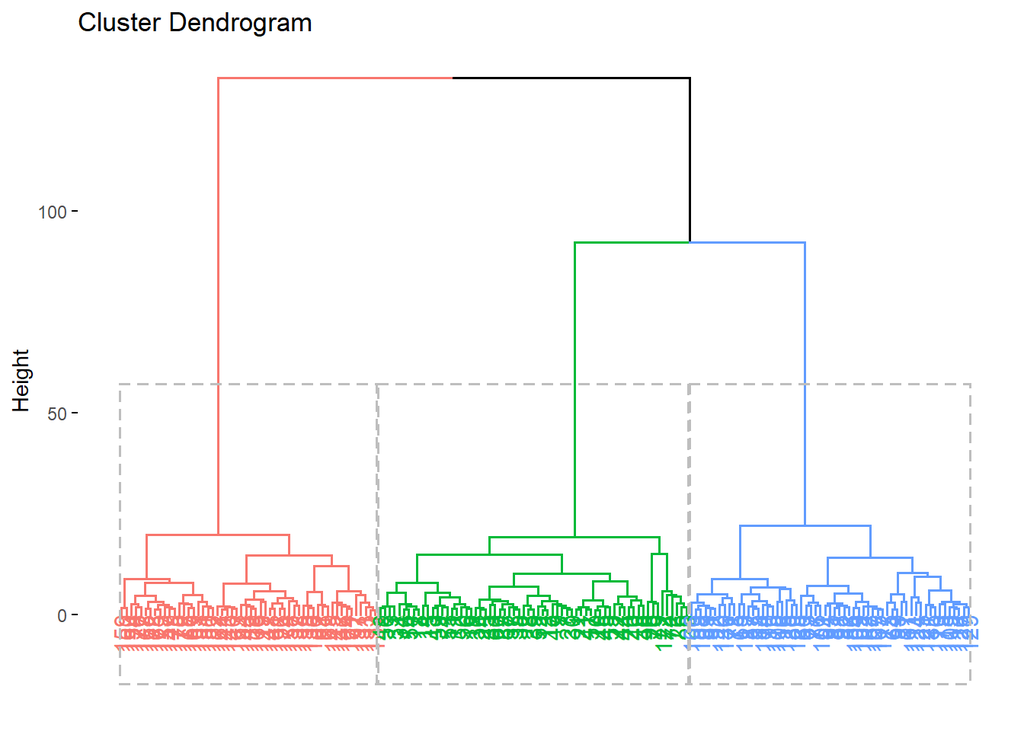

```r
data_5 <-  data[,-1]

# Matriz de distancias euclídeas
d <- dist(data_5, method="euclidean")

# Dendrograma estándar
fviz_dend(hcut(data_5, k=3, hc_method="ward.D"), rect=TRUE)
```

```r
model_hcut <- hcut(data_5, k = 3, hc_method = "ward.D")
```

**(ii) [0.25pt] Haga un PCA con 2 componentes principales y guarde los scores de ambos componentes como nuevas variables.**

```r
# PCA
model_pca <- prcomp(data_5)
model_pca$rotation[,1]
```

```
##         Alcohol           Malic             Ash      Alcalinity       Magnesium
##    -0.144329395     0.245187580     0.002051061     0.239320405    -0.141992042
##         Phenols      Flavanoids   Nonflavanoids Proanthocyanins           Color
##    -0.394660845    -0.422934297     0.298533103    -0.313429488     0.088616705
##             Hue        Dilution         Proline
##    -0.296714564    -0.376167411    -0.286752227
```

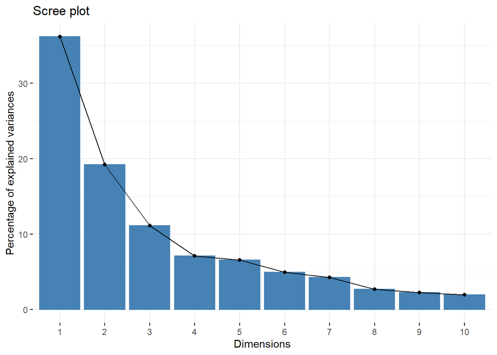

```r
## Seleccion de componentes
# Escojo 2 componentes principales
fviz_eig(model_pca)
```

```r
summary(model_pca)
```

```
## Importance of components:
##                          PC1    PC2    PC3     PC4     PC5     PC6     PC7
## Standard deviation     2.169 1.5802 1.2025 0.95863 0.92370 0.80103 0.74231
## Proportion of Variance 0.362 0.1921 0.1112 0.07069 0.06563 0.04936 0.04239
## Cumulative Proportion  0.362 0.5541 0.6653 0.73599 0.80162 0.85098 0.89337
##                            PC8     PC9   PC10    PC11    PC12    PC13
## Standard deviation     0.59034 0.53748 0.5009 0.47517 0.41082 0.32152
## Proportion of Variance 0.02681 0.02222 0.0193 0.01737 0.01298 0.00795
## Cumulative Proportion  0.92018 0.94240 0.9617 0.97907 0.99205 1.00000
```

**–> Se puede apreciar que con componente 1 y 2 (PC1 , PC2) se puede explicar un 55% de las variables.**

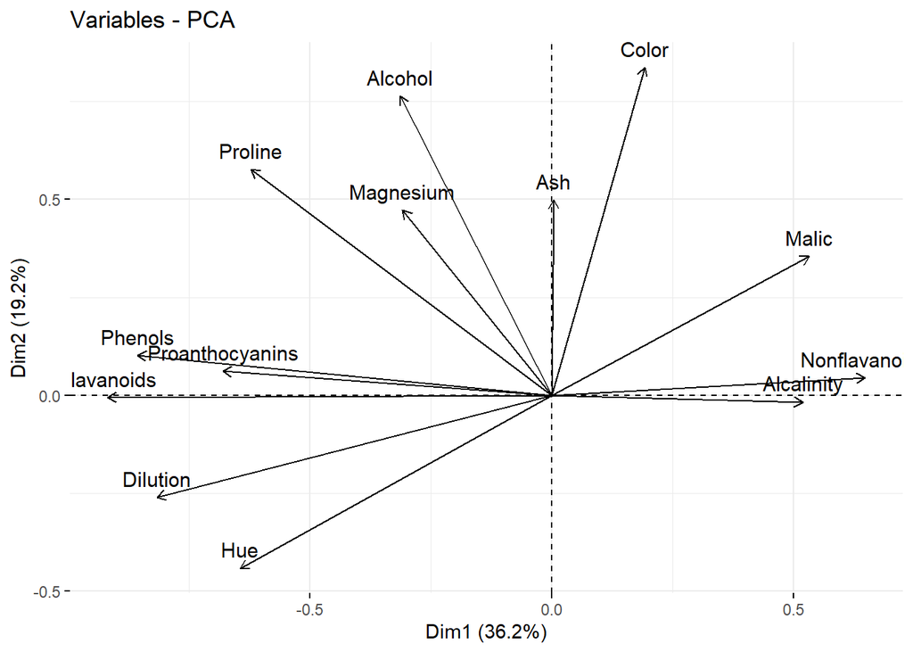

```r
## Grafico de contribucicion  de las variables en PC1 y PC2
fviz_pca_var(model_pca)
```

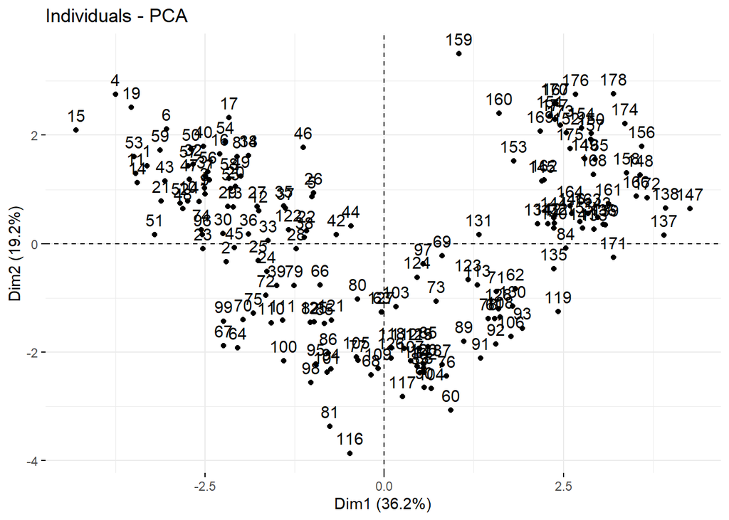

```r
fviz_pca_ind(model_pca)
```

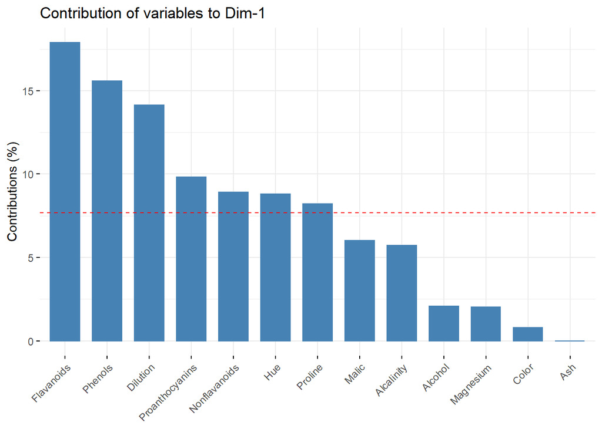

```r
# contribucicion de cada variable en las componentes principales
fviz_contrib(model_pca, choice = "var" , axes = 1)
```

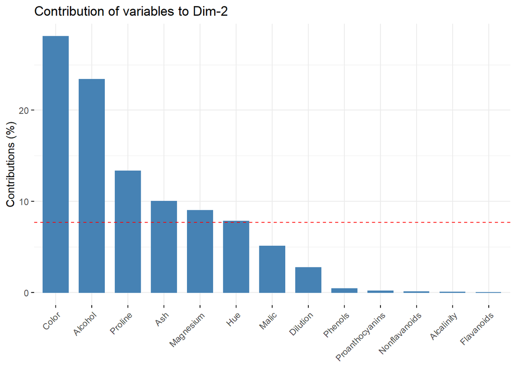

```r
fviz_contrib(model_pca, choice = "var" , axes = 2)
```

```r
# Obtener componentes principales para cada observacion
componentes_principales <- as_tibble(model_pca$x[,1:2])
componentes_principales
```

```
## # A tibble: 178 x 2
##      PC1    PC2
##    <dbl>  <dbl>
##  1 -3.31  1.44
##  2 -2.20 -0.332
##  3 -2.51  1.03
##  4 -3.75  2.75
##  5 -1.01  0.867
##  6 -3.04  2.12
##  7 -2.44  1.17
##  8 -2.05  1.60
##  9 -2.50  0.915
## 10 -2.75  0.787
## # ... with 168 more rows
```

**(iii) [0.25pt] Utilice los scores del ítem anterior para graficar los datos y pinte cada punto según la agrupación calculada con el clustering jerárquico del ítem (i).**

**Grafico de visualizacion de cluster**

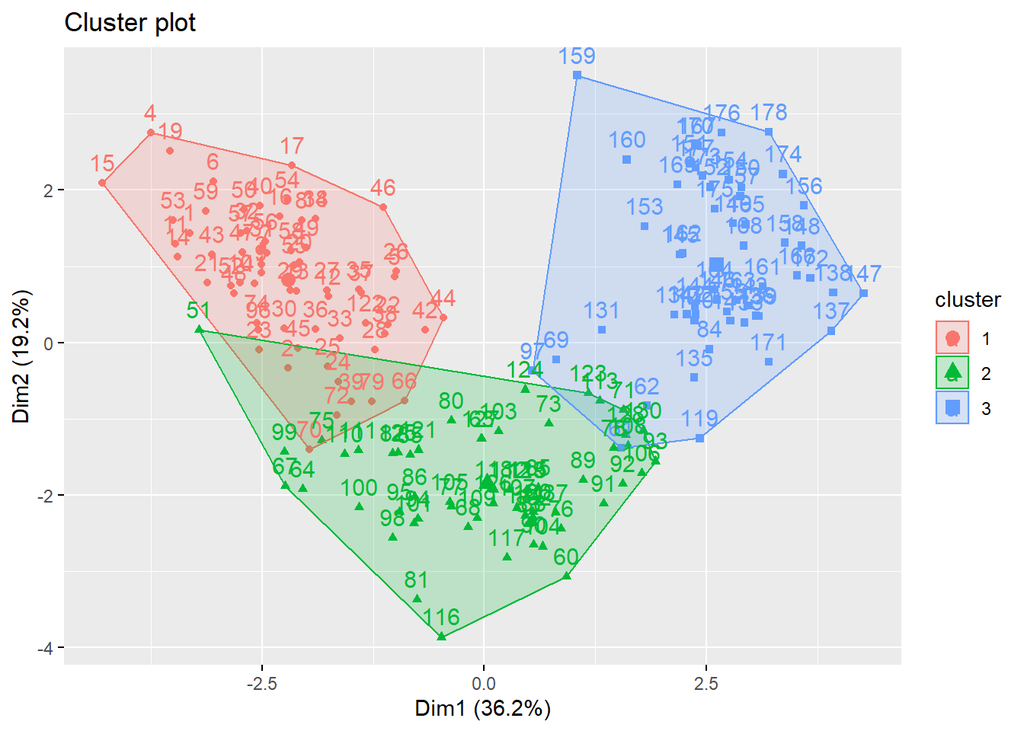

```r
grafico_cluster <- fviz_cluster(model_hcut, data = data_5)
grafico_cluster
```

**(iv) [0.50pt] Haga el mismo gráfico del ítem anterior pero ahora pinte los puntos según el tipo de vino (variable Type). Compare este gráfico con el del ítem (iii) y concluya si la agrupación del clustering jerárquico podría ser un buen clasificador de vinos..**

**Comparacion del grafico_cluster Vs grafico componente type**

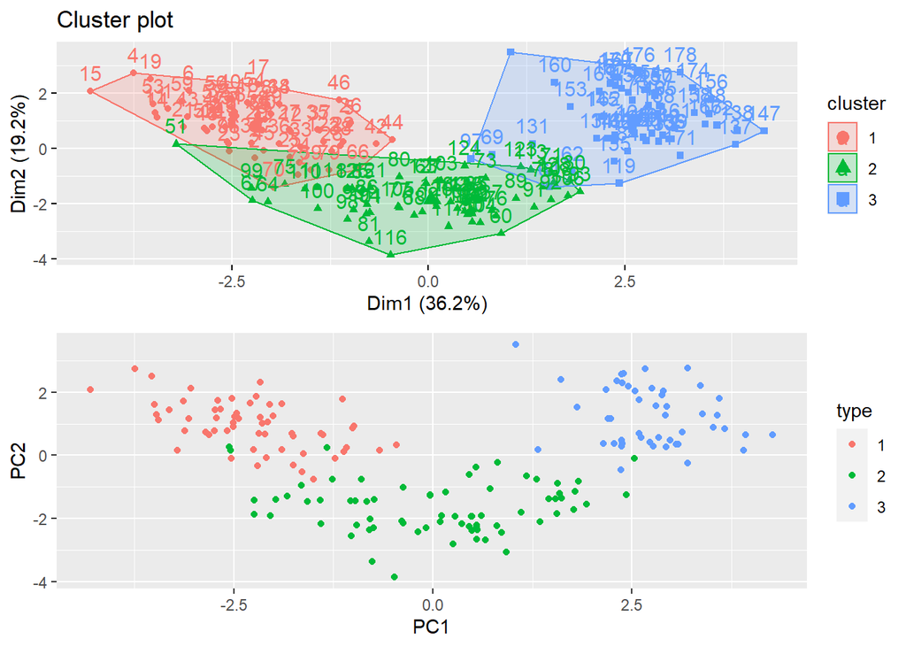

```r
componentes_principales['type'] = data$Type

graficos_componente_type <- ggplot(data = componentes_principales, aes(x=PC1, y=PC2, color=type )) +
  geom_point()



# comparacion del grafico_cluster y graficos_componente_type

grid.arrange(grafico_cluster,graficos_componente_type,  ncol=1)
```

**–>Se puede apreciar que ambos graficos son muy similares. Comparando las clasificaciones hechas por el cluster vs la tipificación de vino, se ven una pequeñas diferencias de clasificación en los bordes de los grupos. De todas formas, podría decir que el cluster de vinos sin ser exacto, clasifica bien**